# Analyzing Movie Ratings

Dennis Jonathan

5/20/2021

## Prerequisites

```r
# Importing the libraries
library(rvest)
library(tidyverse)
# Shutting off warning messages
options(warn=-1)

# Importing the HTML
url <- "http://dataquestio.github.io/web-scraping-pages/IMDb-DQgp.html"
wp_content <- read_html(url)
```

## String Manipulation Self Reminder

We will now remind ourselves of some string manipulation techniques which we have learned previously. After that, we can use those techniques in our HTML data.

```r
# Converting "10.50" to numeric
as.numeric('10.50')
```

```
## [1] 10.5
```

```r
# Converting a vector into numeric
as.numeric(c("14.59", "3.14", "55"))
```

```
## [1] 14.59  3.14 55.00
```

```r
# Parsing numbers from string vectors
parse_number(c("14 min", "17,35", "(2012)", "1,2,3,4"))
```

```
## [1]   14 1735 2012 1234
```

```r
# Removing whitespaces
str_trim(" Spaces before and after should disappear    ")
```

```
## [1] "Spaces before and after should disappear"
```

## Extracting the Data from the HTML

### 1. Extracting Title and Release Year

We will now extract some elements from the header, namely the movie title and its release year. We will need to inspect the HTML formatting for the page. We found out that both the title and the year is in the section called `.lister-item-header`, specifically title is in `.lister-item-header a` and the release year is in `.lister-item-year`. As we have mentioned before, we will only select 30 entries. Since year is contained between two brackets, we will need to use `parse_number()` to just get the thing we want.

```r
# Extracting movie titles
title <- wp_content %>% html_nodes('.lister-item-header a') %>% html_text()

# Extracting release years
year <- wp_content %>% html_nodes('.lister-item-year') %>% html_text() %>% parse_number()
```

### 2. Extracting Runtime and Genre

Next up we will extract the movie’s runtime and its genres. The technique is pretty much the same as extracting the two things above except the information we need now might be contained in other sections. Runtime is contained in the class `.runtime` while Genre is contained in `.genre`. Since the format for runtime is ‘xx min’, we will use `parse_number()` to only get the number of minutes. Genre also contained some whitepaces, thus using `str_trim()` might be useful.

```r
# Extracting the runtime
runtime <- wp_content %>% html_nodes('.runtime') %>% html_text() %>% parse_number()

# Extracting the genre
genre <- wp_content %>% html_nodes('.genre') %>% html_text() %>% str_trim()
```

### 3. Extracting Metacritic Score and IMDB Score

Same thing as before, we will get both ratings from the HTML. Metacritic Score is located in `.ratings-metascore` and IMDB score is located in `.ratings-imdb-rating` in the attribute `data-value`. We need to know that there are some movies which does not have Metascore, IMDB Score or even both. We will deal with the missing data later on. We will also need to convert the both scores into numeric using `as.numeric()`.

```r
# Extracting metascores
meta <- wp_content %>% html_nodes('.metascore') %>% html_text() %>% str_trim() %>% as.numeric()

# Extracting IMDB scores
imdb <- wp_content %>% html_nodes(".ratings-imdb-rating") %>% html_attr("data-value") %>% as.numeric()
```

#### 4. Extracting Movie Votes

The last but not the least, we will extract movie votes from the page. Movie votes is located in `.sort-num_votes-visible :nth-child(2)` and we will need to use `parse_number()` to only get the numerics.

```r
# Extracting the movie votes
mv <- wp_content %>% html_nodes('.sort-num_votes-visible :nth-child(2)') %>% html_text() %>% parse_number()
```

## Data Cleaning

The data cleaning process will include filling in some missing values in the vectors. We will use the function `append_vector()` which is given to fill the missing values according to the index (which is the distance to the previous non-missing index). After filling the missing values, we will create a dataframe We will also drop the 17th row (a row which has a lot of missing values) from the final dataframe.

```r
# Function to append vectors
append_vector <- function(vector, inserted_indices, values){

  ## Creating the current indices of the vector
  vector_current_indices <- 1:length(vector)

  ## Adding small amount of values (between 0 and 0.9) to the `inserted_indices`
  new_inserted_indices <- inserted_indices + seq(0, 0.9, length.out = length(inserted_indices))

  ## Appending the `new_inserted_indices` to the current vector indices
  indices <- c(vector_current_indices, new_inserted_indices)

  ## Ordering the indices
  ordered_indices <- order(indices)

  ## Appending the new value to the existing vector
  new_vector <- c(vector, values)

  ## Ordering the new vector wrt the ordered indices
  new_vector[ordered_indices]
}

# Filling in the missing data in Metascore
meta <- append_vector(meta, c(1, 1, 1, 13, 24), NA)

# Dropping the 17th row.
title <- title[-17]
year <- year[-17]
runtime <- runtime[-17]
genre <- genre[-17]
meta <- meta[-17]
```

We will now create a dataframe out of all the vectors.

```r
# Creating a dataframe
df <- tibble('title' = title,
             'year' = year,
             'runtime' = runtime,
             'genre' = genre,
             'metascore' = meta,
             'rating' = floor(imdb),
             'vote' = mv)
```

## Visualizing the Datatrame

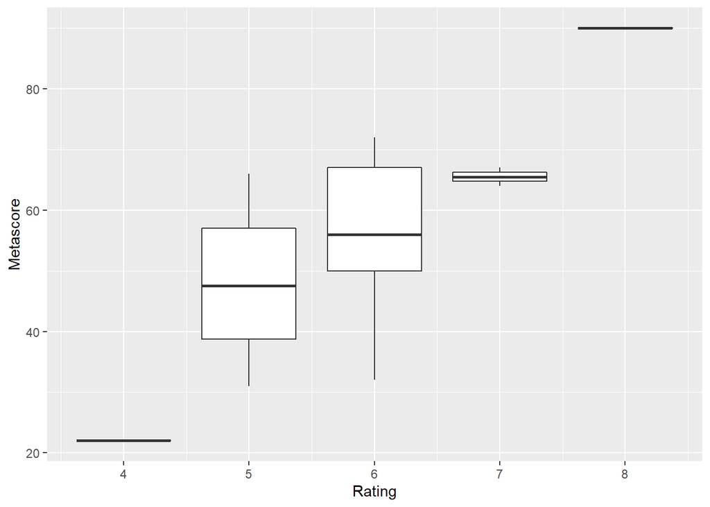

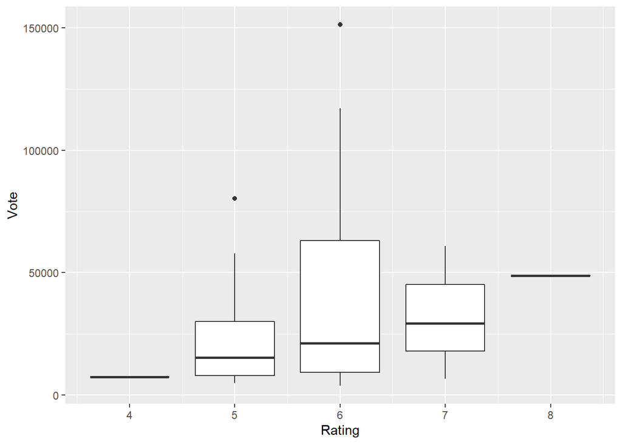

```r
for (i in c('metascore', 'vote')){
  print(df %>% ggplot(aes(x = rating, y = df[[i]], group = rating)) + geom_boxplot()
        + labs(x = tools::toTitleCase('Rating'), y = tools::toTitleCase(i)))
  }
```